# The prognosis of a first seizure or seizure-like events a prospective single-center study

Version V4

01/10/2020

# Data dictionary

1. **database**: The data acquisition was done in two steps, this variable specifies to which of the steps the data point belongs, type character
2. **ordre**: Order in which the patients were entered in the database, type numeric
3. **code.pat**: code attributed to each patient, type character
4. **age**: Patient’s age, type numeric
5. **genre**: Patient’s gender, type character
6. **atcd.enfance**: Relevant medical history of the patient during his childhood, type character
7. **atcd.famille**: Relevant medical history of the patient’s close family, type character
8. **date.1st.EEG**: Date of the first standard EEG after the index event, type Date (lubridate)
9. **res.1st.EEG**: Result of the first EEG (normal, abnormal, none, none but proposed), type character
10. **pointes.1st.EEG**: Presence of epileptic spikes on the standard EEG (focal, generalised, NA), type character
11. **slow.1st.EEG**: Presence of a slowing or non-epileptic abnormalities on the standard EEG (focal, generalised, NA), type character
12. **tt.1st.EEG**: Drugs active during the standard EEG that could have reduce the spike detection (none, BZD, AED, antidepressant, neuroleptics, other, none/other, NA), type character
13. **res.lt.EEG**: Result of the first long-term EEG (normal, abnormal, none, none but proposed), type character
14. **pointes.lt.EEG**: Presence of epileptic spikes on the LT EEG (focal, generalised, NA), type character
15. **slow.lt.EEG**: Presence of a slowing or non-epileptic abnormalities on the LT EEG (focal, generalised, NA), type character
16. **tt.lt.EEG**: Drugs active during the LT EEG that could have reduce the spike detection (none, BZD, AED, antidepressant, neuroleptics, other, none/other, NA), type character
17. **normal.1st.lt.EEG**: Combination of the normality information of the standard and LT EEG, type character
18. **date.CT**: Date of the realisation of the first CT after the index event, type Date(lubridate)
19. **res.CT**: Result of the brain CT (normal, abnormal, none, none but proposed). abnromal CT contain all types of abnormalities: epileptogenic or not, type character
20. **les.CT**: Type of abnormalities (dementia, vascular, tumor, malformation, unknown, none, NA), type = character
21. **res.IRM**: Result of the brain MRI (normal, abnormal, none, none but proposed). abnromal MRI contain all types of abnormalities: epileptogenic or not, type character
22. **date.IRM**: date of the first MRI after first event, type Date (lubridate) 23.**les.IRM**: Type of abnormalities (dementia, vascular, tumor, malformation, unknown, none, NA), type = character
23. **les.epi**: Combined information of CT and MRI specifying if the lesion is epileptogenic, non-epileptogenic, suspicious, or normal
24. **date.1st.cs.su**: Date of the first consultation to the emergency department (ED) after the index event, type POSIXct
25. **date.1st.cs.epi**: Date of the first consultation in the epileptology unit of the HUG, type POSIXct
26. **dx.final**: Final diagnosis (Acute symptomatic seizure (crise provoquee), unknown, cardiovascular origin, psychogenic, other, epilepsy (crise epilepsie) vaso-vagal syncopes, cardiac origin, cardiac) retained after 2 years follow-up (for patients for whom the follow-up information was available), type character
27. **type.epi.final**: For patients with dx.final == crise epilepsie, specification of the epilepsy type (NA, non-lesional, idiopathic generalised (IGE), unknown), type character
28. **dx.final.margitta**: Correction of the diagnosis a posteriori by MS, type character
29. **cat.dx.final**: To be removed, type logical
30. **resident**: to understand why patients were lost in follow-up, infromation of where the patients are living (TRUE = Geneva’s area, FALSE = other canton or country), type logical
31. **veille.sommeil**: Did the event happened during sleep or wake time, type character
32. **status.neuro**: Results of the neuro status (normal, abnormal, none, none but proposed), type character
33. **commentaire**: Brief description of the cases in french, type character
34. **n.ret.SU**: Number of times a patient came back to the ED for a relapse, type numeric
35. **n.recidives.rapp**: Number of reported relapses in consultations, type numeric
36. **n.tot.recidives**: Number of total relapses combining reported and ED consultations, type numeric
37. **type.resident**: Description if the patient lives in another canton, country, had the first seizure while traveling…, type character
38. **SBB.1**: Number of seizures before the index event (1 = first seizure, 2 = one seizure before the index event, 3 = more than one seizure before the index event), type = numeric
39. **SBB.2**: Trajectory of the patients after the ED (1 = hospitalisation, 2 = ambulatory cares or lost, 4 = hospitalisation but with an admission in the intensive care unit before), type = numeric
40. **SBB.3**: Trajectory of patients after the ED (1 = hospitalisation in epileptology, 2 = hospitalisation in neurology, 3 = hospitalised in the intensive care unit and lost, 4 = hospitalised in neurosurgery, 5 = hospitalised in psychiatry, 6 = hospitalised in another service, 7 = specialised ambulatory cares, 8 = followed outside the hospital or lost), type numeric
41. **SBB.4**: Long term follow-up information for patients with SBB.3 = 7 (1 = other specialised follow-up, 2 = epileptology, 3 = neurology, 4 = neurosurgery, 5 = psychatry), type = numeric
42. **SBB.5**: Trajectory of patients followed-up in epileptology
43. follow-up of 12 to 24 months
44. follow-up by a private neurologist after a 3 months follow-up in the epileptology unit
45. follow-up by the neurology service after a 3 months follow-up in the epileptology unit
46. follow-up of 3 to 6 months in the epileptology unit and then stop because not needed
47. follow-up of 3 to 6 months in the epileptology unit and then followed-up by a private neurologist
48. follow-up of 6 to 12 months in the epileptology unit and then follow-up not needed anymore
49. follow-up of 6 to 12 months in the epileptology unit and then followed-up by a private neurologist
50. follow-up of 6 to 12 months in the epileptology unit and then followed-up by another service
51. follow-up of 3 to 6 months in the epileptology unit and then followed-up by another service
52. follow-up by the neurosurgery service after a 3 months follow-up in the epileptology unit
53. follow-up by another service after a 3 months follow-up in the epileptology unit
54. 3 months follow-up in the epileptology unit and then lost
55. 3 months follow-up in the epileptology unit and then follow-up not needed anymore
56. follow-up of 3 to 6 months in the epileptology unit and then patient lost
57. follow-up of 3 to 6 months in the epileptology unit and then follow-up not needed
58. follow-up of 6 to 12 months in the epileptology unit and then patient lost
59. follow-up of 6 to 12 months in the epileptology unit and then follow-up not needed
60. after a follow-up of 12 to 24 months in epileptology, follow-up scheduled
61. after a follow-up of 12 to 24 months in epileptology, patient lost
62. after a follow-up of 12 to 24 months in epileptology, follow-up not needed
63. Follow-up in epileptology at 3 months and then the patient deceased
64. Follow-up in epileptology at 3 to 6 months and then the patient deceased
65. Follow-up in epileptology at 6 to 12 months and then the patient deceased
66. Follow-up in epileptology at 12 to 24 months and then the patient deceased
67. **doute.critere**: Patients for whom the inclusion criteria have been discussed, type logical
68. **date.1st.1st.sz**: Date of the first event event before the index event, type Date (lubridate)
69. **date.2nd.1st.sz**: Date of an eventual second event before the index event, type POSIXct
70. **date.dern.1st.sz**: In case of more than 2 seizures before the index event, date of the last event before the index one, type POSIXct
71. **date.adm.si**: Date of hospitalisation in the intensive care unit, type POSIXct
72. **date.sortie.si**: Date of the end of hospitalisation in the intensive care unit, type Date (lubridate)
73. **date.1st.cs.neuro**: Date of the first consultation in the neurology service, type POSIXct
74. **date.dern.cs.neuro**: Date of the last consultation in the neurology service, type POSIXct
75. **raison_stop_suivi.neuro**: Motive of the interruption of follow-up by the neurology service, type character
76. **date.1st.cs.neurochir**: Date of the first consultation in the neurosurgery service, type POSIXct
77. **date.dern.cs.neurochir**: Date of the last consultation in the neurosurgery service, type POSIXct
78. **raison_stop_suivi.neurochir**: Motive of the interruption of follow-up by the neurosurgery service, type character
79. **date.1st.cs.psy**: Date of the first consultation in the psychiatry service, type POSIXct
80. **date.dern.cs.psy**: Date of the last consultation in the psychiatry service, type POSIXct
81. **raison_stop_suivi.psy**: Motive of the interruption of follow-up by the psychiatry service, type character
82. **date.1st.cs.autre**: Date of the first consultation in another service, type POSIXct
83. **date.dern.cs.autre**: Date of the last consultation in anothers ervice, type POSIXct
84. **raison_stop_suivi.autre**: Motive of the interruption of follow-up by another service, type character
85. **type_suivi.autre**: By which other service the patient was followed-up, type character
86. **date.dern.cs.epi**: Date of the last consultation in the epileptology unit, type POSIXct
87. **date.entree.1st.hospit**: Date of hospitalisation of the patient, type POSIXct
88. **srv.1st.hospit.si_autre**: If SBB.3 = 6, in which service the patient was hospitalised, type character
89. **date.debut.tt**: Date at which the anti-epileptic drug was prescribed, type POSIXct
90. **date.fin.tt**: Date of the end of treatment, type POSIXct
91. **date.dx.final**: Date at which the final diagnosis was announced to the patient, type Date (lubridate)
92. **date.deces**: Date of decease, type POSIXct
93. **cause.deces**: Origin of the death, type character
94. **date.entree.2nd.hospit**: In case of a second hospitalisation after the seizure (seizure –> emergency dept. –> hospitalisation –> 2nd hospitalisation), date of entry in the service, type POSIXct
95. **date.sortie.2nd.hospit**: In case of a second hospitalisation after the first seizure, date of release from the hospital, type POSIXct
96. **srv.2nd.hospit**: Medical service in which the second hospitalisation took place, type character
97. **type.1st.sz**: type of the first seizure (secondary generalized seizures; focals, generalized, acute symptomatic, unknown), type character
98. **type.principal.seizure**: Main type of seizure experienced by a patient, type character
99. **dx.initial**: diagnosis proposed after the first consultation, type character
100. **type.epi.initial**: Epilepsy type proposed after the first consultation, type character
101. **type.autre.initial**: For patients who recieved the diagnosis other, specification of the origin of the episode after the first consultation, type character
102. **type.autre.final**: For patients who recieved the diagnosis other, specification of the origin of the episode after 2 years follow-up, type character
103. **type.cardiovasculaire**: For the patients who recived the diagnosis of cardiovascular origin to their first event, description of the type of cardiovascular disease, type character
104. **date.sortie.1st.hospit**: Date of release after the first hospitalisation, type POSIXct
105. **review.dx**: Patients for whom the diagnosis needed a review, irrelevant column, type logical
106. **AED**: Is the patient under anti-epileptic drug ? type logical
107. **EEG.result_resume**: Summary column groupping the information of the different modalities of pointes.1st.EEG and slow.1st.EEG, type character
108. **EEG.lt.result_resume**: Summary column groupping the information of the different modalities of pointes.lt.EEG and slow.lt.EEG, type character
109. **operated**: Has the patient been operated ? type logical
110. **ATCD_specific**: Description of the medical history before the first event, type character
111. **les.progressive**: For patients who showed a brain lesion, specification if the lesion was progressive or not, type character
112. **type_EGI**: For patients with generalized epilepsy, specification of the type of generalized epilepsy, type character
113. **motif_relapse**: For epileptic patients, verification by a MD if relapses are indeed true relapses, type character
114. **detail_relapse**: For epileptic patients, column indicating the type of relapse, type character
115. **commentaire_relapse**: Text either describing a comment about the relapse, or the date of the first relapse
116. **dx.general**: Reformulation of the column dx.final (Epileptic seizure, non-epileptic event, unknown), type character
117. **dx.event**: Reformulation of the column dx.final (Acute syptomatic seizure, Epilepsy, cardiovascular…), type character
118. **dx.epi**: Reformulation of the column dx.final and type.epi.final (focal vs. generalized), type character

# Method

```r
# N pat
tot_pat <- nrow(data_full_cleaned)

# N patients admited in the ED
N_pat_adm_ED <- nrow(data_full_cleaned%>%filter(!is.na(date.1st.cs.su)))

pct_pat_adm_ED <- pct.fun(nrow(data_full_cleaned%>%filter(!is.na(date.1st.cs.su))), nrow(data_full_cleaned%>%filter(!is.na(code.pat))))
```

We reviewed the charts between 3/2010 and 3/2017 of 1011 patients for whom a first epileptic seizure was suspected.

Most of the patients were admitted in the ED (90.8%; N = 918/1011), the remainder on the ward outside the neurology clinic.

```r
data_dead <- data_full_cleaned%>%
  dplyr::mutate(alive = ifelse(!is.na(date.deces) | !is.na(cause.deces), "dead", "alive"),
                dx.dicho = ifelse(dx.event == "Epilepsy", "epi", "non-epi"),
                dx.dicho = ifelse(is.na(dx.dicho), "non-epi", dx.dicho))%>%
  dplyr::group_by(alive)%>%
  dplyr::summarise(N = n(),
            mean_age = round(mean(age),2),
            sd_age = round(sd(age),2))

data_resid <- data_full_cleaned%>%
  group_by(resident)%>%
  summarise(N = n())

other_lost <- nrow(data_full_cleaned%>%
  filter(SBB.3 == 3 | SBB.3 == 8)%>%
  filter(resident == TRUE)%>%
  filter(is.na(date.deces)))

tot_lost <- data_dead$N[2]+data_resid$N[1]+other_lost
```

Tracing of the patients was achieved using the information retrieved from the electronical medical records within the Geneva University Hospital for the next two years following the first event. Only patients with a complete work-up were retained, however, some patients were lost (N = 337), either because of death (N = 114), leaving the area (N = 116), or without clear motive (N = 107).

# Results

```r
##-----------------------------------------------------------------------
##  Creation of the summary tables for each step of the diagnostic tree
##-----------------------------------------------------------------------

# first step

data_full_cleaned%>%
  summarise(N = n(), age.pat = mean(age), sd = sd(age))
```

```
## # A tibble: 1 x 3
##       N age.pat    sd
##   <int>   <dbl> <dbl>
## 1  1011    53.1  21.7
```

```r
data_full_cleaned%>% group_by(genre)%>%
  summarise(N = n(), age.pat = mean(age), sd = sd(age))
```

```
## # A tibble: 2 x 4
##   genre     N age.pat    sd
##   <chr> <int>   <dbl> <dbl>
## 1 F       441    55.1  21.8
## 2 H       570    51.6  21.6
```

```r
# second step

data_full_cleaned%>%
  group_by(dx.general)%>%
  summarise(N = n(), age.pat = mean(age), sd = sd(age))
```

```
## # A tibble: 3 x 4
##   dx.general              N age.pat    sd
##   <chr>               <int>   <dbl> <dbl>
## 1 Epileptic seizure     585    53.6  21.3
## 2 Non epileptic event   350    52.5  22.4
## 3 Unknown                76    51.8  21.5
```

```r
data_full_cleaned%>% group_by(dx.general, genre)%>%
  summarise(N = n(), age.pat = mean(age), sd = sd(age))
```

```
## # A tibble: 6 x 5
## # Groups:   dx.general [3]
##   dx.general          genre     N age.pat    sd
##   <chr>               <chr> <int>   <dbl> <dbl>
## 1 Epileptic seizure   F       223    56.8  21.2
## 2 Epileptic seizure   H       362    51.7  21.3
## 3 Non epileptic event F       182    52.9  22.8
## 4 Non epileptic event H       168    52.1  22.0
## 5 Unknown             F        36    55.4  19.6
## 6 Unknown             H        40    48.6  22.9
```

```r
# Third step

data_full_cleaned%>%
  group_by(dx.general,dx.event)%>%
  summarise(N = n(), age.pat = mean(age), sd = sd(age))
```

```
## # A tibble: 9 x 5
## # Groups:   dx.general [3]
##   dx.general          dx.event                                N age.pat    sd
##   <chr>               <chr>                               <int>   <dbl> <dbl>
## 1 Epileptic seizure   Acute symptomatic seizure              42    50.2  21.0
## 2 Epileptic seizure   Epilepsy                              475    54.8  21.2
## 3 Epileptic seizure   Unknown                                68    47.8  22.1
## 4 Non epileptic event Cardiac                                17    72.1  17.4
## 5 Non epileptic event Cardiovascular                         56    65.1  23.2
## 6 Non epileptic event Other                                 144    54.8  21.1
## 7 Non epileptic event Psychogenic non epileptic seizure      67    38.1  16.8
## 8 Non epileptic event Vaso-vagal and orthostatic syncopes    66    46.5  20.0
## 9 Unknown             <NA>                                   76    51.8  21.5
```

```r
data_full_cleaned%>%
  group_by(dx.general,dx.event, genre)%>%
  summarise(N = n(), age.pat = mean(age), sd = sd(age))
```

```
## # A tibble: 18 x 6
## # Groups:   dx.general, dx.event [9]
##    dx.general         dx.event                         genre     N age.pat    sd
##    <chr>              <chr>                            <chr> <int>   <dbl> <dbl>
##  1 Epileptic seizure  Acute symptomatic seizure        F        12    56   24.2
##  2 Epileptic seizure  Acute symptomatic seizure        H        30    47.8 19.5
##  3 Epileptic seizure  Epilepsy                         F       186    58.1 20.7
##  4 Epileptic seizure  Epilepsy                         H       289    52.7 21.2
##  5 Epileptic seizure  Unknown                          F        25    47.6 21.7
##  6 Epileptic seizure  Unknown                          H        43    47.9 22.5
##  7 Non epileptic eve~ Cardiac                          F         7    81.1  7.54
##  8 Non epileptic eve~ Cardiac                          H        10    65.8 19.8
##  9 Non epileptic eve~ Cardiovascular                   F        28    68.7 24.1
## 10 Non epileptic eve~ Cardiovascular                   H        28    61.5 22.1
## 11 Non epileptic eve~ Other                            F        79    55.0 21.3
## 12 Non epileptic eve~ Other                            H        65    54.6 21.0
## 13 Non epileptic eve~ Psychogenic non epileptic seizu~ F        40    38.9 15.7
## 14 Non epileptic eve~ Psychogenic non epileptic seizu~ H        27    36.8 18.5
## 15 Non epileptic eve~ Vaso-vagal and orthostatic sync~ F        28    44.4 19.6
## 16 Non epileptic eve~ Vaso-vagal and orthostatic sync~ H        38    47.9 20.4
## 17 Unknown            <NA>                             F        36    55.4 19.6
## 18 Unknown            <NA>                             H        40    48.6 22.9
```

```r
# Fourth step

data_full_cleaned%>%
  group_by(dx.event, dx.epi)%>%
  summarise(N = n(), age.pat = mean(age), sd = sd(age))
```

```
## # A tibble: 10 x 5
## # Groups:   dx.event [9]
##    dx.event                         dx.epi                       N age.pat    sd
##    <chr>                            <chr>                    <int>   <dbl> <dbl>
##  1 Acute symptomatic seizure        <NA>                        42    50.2  21.0
##  2 Cardiac                          <NA>                        17    72.1  17.4
##  3 Cardiovascular                   <NA>                        56    65.1  23.2
##  4 Epilepsy                         Focal epilepsy             444    56.8  20.3
##  5 Epilepsy                         Primary generalized epi~    31    26.4  10.8
##  6 Other                            <NA>                       144    54.8  21.1
##  7 Psychogenic non epileptic seizu~ <NA>                        67    38.1  16.8
##  8 Unknown                          <NA>                        68    47.8  22.1
##  9 Vaso-vagal and orthostatic sync~ <NA>                        66    46.5  20.0
## 10 <NA>                             <NA>                        76    51.8  21.5
```

```r
data_full_cleaned%>%
  group_by(dx.event, dx.epi, genre)%>%
  summarise(N = n(), age.pat = mean(age), sd = sd(age))
```

```
## # A tibble: 20 x 6
## # Groups:   dx.event, dx.epi [10]
##    dx.event                     dx.epi                 genre     N age.pat    sd
##    <chr>                        <chr>                  <chr> <int>   <dbl> <dbl>
##  1 Acute symptomatic seizure    <NA>                   F        12    56   24.2
##  2 Acute symptomatic seizure    <NA>                   H        30    47.8 19.5
##  3 Cardiac                      <NA>                   F         7    81.1  7.54
##  4 Cardiac                      <NA>                   H        10    65.8 19.8
##  5 Cardiovascular               <NA>                   F        28    68.7 24.1
##  6 Cardiovascular               <NA>                   H        28    61.5 22.1
##  7 Epilepsy                     Focal epilepsy         F       171    60.7 19.3
##  8 Epilepsy                     Focal epilepsy         H       273    54.3 20.5
##  9 Epilepsy                     Primary generalized e~ F        15    28.1  9.18
## 10 Epilepsy                     Primary generalized e~ H        16    24.8 12.3
## 11 Other                        <NA>                   F        79    55.0 21.3
## 12 Other                        <NA>                   H        65    54.6 21.0
## 13 Psychogenic non epileptic s~ <NA>                   F        40    38.9 15.7
## 14 Psychogenic non epileptic s~ <NA>                   H        27    36.8 18.5
## 15 Unknown                      <NA>                   F        25    47.6 21.7
## 16 Unknown                      <NA>                   H        43    47.9 22.5
## 17 Vaso-vagal and orthostatic ~ <NA>                   F        28    44.4 19.6
## 18 Vaso-vagal and orthostatic ~ <NA>                   H        38    47.9 20.4
## 19 <NA>                         <NA>                   F        36    55.4 19.6
## 20 <NA>                         <NA>                   H        40    48.6 22.9
```

```r
# Fifth step

data_full_cleaned%>%
  filter(type.epi.final == "lesionnelle")%>%
  summarise(N = n(), age.pat = mean(age), sd = sd(age))
```

```
## # A tibble: 1 x 3
##       N age.pat    sd
##   <int>   <dbl> <dbl>
## 1   384    58.4  19.6
```

```r
data_full_cleaned%>%
  filter(type.epi.final == "non lesionnelle")%>%
  summarise(N = n(), age.pat = mean(age), sd = sd(age))
```

```
## # A tibble: 1 x 3
##       N age.pat    sd
##   <int>   <dbl> <dbl>
## 1    60    46.5  21.7
```

```r
data_full_cleaned%>%
  group_by(genre)%>%
  filter(type.epi.final == "lesionnelle")%>%
  summarise(N = n(), age.pat = mean(age), sd = sd(age))
```

```
## # A tibble: 2 x 4
##   genre     N age.pat    sd
##   <chr> <int>   <dbl> <dbl>
## 1 F       149    61.8  18.8
## 2 H       235    56.2  19.7
```

```r
data_full_cleaned%>%
  group_by(genre)%>%
  filter(type.epi.final == "non lesionnelle")%>%
  summarise(N = n(), age.pat = mean(age), sd = sd(age))
```

```
## # A tibble: 2 x 4
##   genre     N age.pat    sd
##   <chr> <int>   <dbl> <dbl>
## 1 F        22    53    21.0
## 2 H        38    42.8  21.5
```

```r
# N female patients
N_fem <- nrow(data_full_cleaned[data_full_cleaned$genre == "F",])

# Mean age
M_SD_age <- data_full_cleaned%>%summarise(M_age = round(mean(age),1),
                                          SD_age = round(sd(age),1))
#range age
range_age <- range(data_full_cleaned$age)

# N patients with epileptic seizure
N_epi_sz <- data_full_cleaned%>%
  filter(dx.general == "Epileptic seizure")%>%
  summarise(N_epi_sz = n(),
            pct_epi_sz = pct.fun(N_epi_sz, tot_pat))

# N patients acute symptomatic seizure

tot_epi_sz <- nrow(data_full_cleaned[data_full_cleaned$dx.general == "Epileptic seizure",])

N_acute <- data_full_cleaned%>%
  filter(dx.event == "Acute symptomatic seizure")%>%
   summarise(N_acute = n(),
            pct_acute_tot = pct.fun(N_acute, tot_pat),
            pct_acute_epi = pct.fun(N_acute, tot_epi_sz))

# cause non-epileptic nature
non_epi <- data_full_cleaned%>%
  filter(dx.general == "Non epileptic event")%>%
  summarise(N_non_epi = n(),
            pct_non_epi = pct.fun(N_non_epi, tot_pat))

# N pat_per dx
tot_non_epi <- nrow(data_full_cleaned%>%filter(dx.event != "Epilepsy" | is.na(dx.event)))

N_dx_event <- data_full_cleaned%>%
  group_by(dx.event)%>%
  summarise(N = n(),
            pct_tot = pct.fun(N,tot_pat),
            pct_non_epi = pct.fun(N,tot_non_epi))

# Types of Other diagnoses

table_1<- data_full_cleaned%>%group_by(type.autre.final)%>%summarise(N = n())%>%arrange(desc(N))%>%filter(!is.na(N))

# Not the first event
tot_pat <- nrow(data_full_cleaned%>%filter(!is.na(code.pat)))
N_not_first_event <- nrow(data_full_cleaned%>%filter(SBB.1 > 1))
pct_not_first_event <- pct.fun(nrow(data_full_cleaned%>%filter(SBB.1 > 1)), nrow(data_full_cleaned%>%filter(!is.na(code.pat))))

# N patients admited in the ED
N_pat_adm_ED <- nrow(data_full_cleaned%>%filter(!is.na(date.1st.cs.su)))

pct_pat_adm_ED <- pct.fun(nrow(data_full_cleaned%>%filter(!is.na(date.1st.cs.su))), nrow(data_full_cleaned%>%filter(!is.na(code.pat))))
```

We included 1011 patients, 441 women, with a mean age of 53.1 (SD= 21.7) years, ranging from 16 to 98. In 7.42% (N = 75/1011) detailed patient history showed that the index event was not the first one. Most patients were diagnosed with an epileptic event (N = 585/1011; 57.86%), of which 42 presented an acute symptomatic seizure (4.15% of the total sample or 7.18% of all patients with an epileptic seizure). Non-epileptic events were found in 34.62% (350/1011). Sixty-seven patients presented psychogenic non-epileptic seizures (6.63%), transient ischemic attack in 56 (5.54%), vasovagal syncope in 66 (6.53%), and true cardiac syncope in 17 (1.68%).

In 144 patients (14.24%), various other causes were found; table 1 shows the details.

```r
nrow(data_full_cleaned%>%
       filter(dx.event == "Unknown")%>%
       filter(SBB.3 == 8 | SBB.3 == 3| !is.na(date.deces) | resident == FALSE))
```

```
## [1] 24
```

| type.autre.final | N |
| --- | --- |
| NA | 865 |
| indet non epi | 35 |
| ECA | 16 |
| IAT | 14 |
| migraine avec aura | 7 |
| multifactoriel | 5 |
| tr. Sensitifs peripheriques | 5 |
| malaise d’origine iatrogene | 4 |
| intoxication | 3 |
| malaise sur dumping | 3 |
| malaise vestibulaire | 3 |
| migraine acompagnee | 3 |
| migraine basilaire | 3 |
| troubles attentionnels | 3 |
| burn-out | 2 |
| cephalees | 2 |
| hyperglycemie | 2 |
| migraines sans aura | 2 |
| amnesie transitoire d’origine indeterminee | 1 |
| anxiete | 1 |
| arret cardiorespiratoire idiopathique | 1 |
| chute sur PC | 1 |
| coma hypoglycemique | 1 |
| convulsions sur insuffisance respiratoires | 1 |
| cupulolithiase | 1 |
| denutrition | 1 |
| DMLA | 1 |
| Douleurs neurogènes d’origine centrale | 1 |
| encephalopathie hypertensive | 1 |
| endormissement | 1 |
| HSD | 1 |
| hydrocephalie | 1 |
| hypertonie spastique | 1 |
| hypoglycemie | 1 |
| hypotension | 1 |
| hypoventilation | 1 |
| manifestation de la tumeur | 1 |
| migraine | 1 |
| narcolepsie | 1 |
| oncologique non cerebrale | 1 |
| origine orthostatique | 1 |
| parasomnie | 1 |
| park | 1 |
| SEP | 1 |
| sevrage OH | 1 |
| somnolence | 1 |
| steakhouse syndrome | 1 |
| syncope sur anesthésie dentaire | 1 |
| syncope sur prise d’antalgique | 1 |
| syndrome de Lewis-Sumner | 1 |
| tr. Neuro sur masse | 1 |
| vertiges sur cavernomatose | 1 |

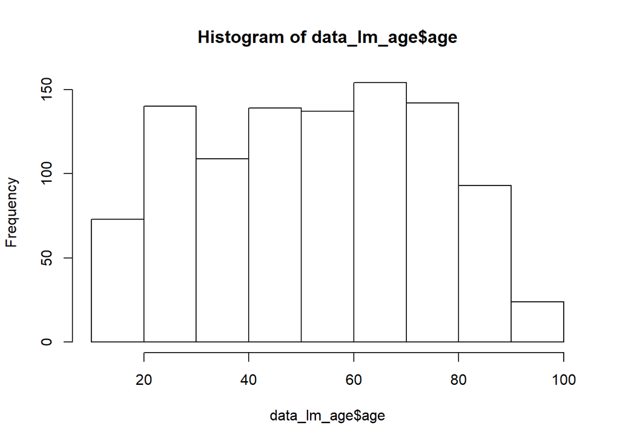

```r
# ANOVA on age:


data_lm_age <- data_full_cleaned%>%
  mutate(more_1_event = ifelse(SBB.1 > 1, "many", "one"))%>%
  mutate(dx_paste = ifelse(dx.event == "Epilepsy", paste(dx.event, type.epi.final),dx.event))%>%
  select(code.pat, age, dx.event, dx.epi,  more_1_event, dx_paste, genre, les.epi)

hist(data_lm_age$age)
```

```r
model_age <- lm(age ~  dx.event + more_1_event + genre + les.epi, data = data_lm_age)
vif(model_age)
```

```
##                  GVIF Df GVIF^(1/(2*Df))
## dx.event     1.591275  7        1.033738
## more_1_event 1.026246  1        1.013038
## genre        1.030029  1        1.014903
## les.epi      1.534388  4        1.054974
```

```r
anova(model_age)
```

```
## Analysis of Variance Table
##
## Response: age
##               Df Sum Sq Mean Sq F value    Pr(>F)
## dx.event       7  36133  5161.8 13.1814 2.942e-16 ***
## more_1_event   1     80    80.1  0.2045  0.651227
## genre          1   3060  3059.8  7.8135  0.005294 **
## les.epi        4  41735 10433.7 26.6439 < 2.2e-16 ***
## Residuals    920 360272   391.6
## ---
## Signif. codes:  0 '***' 0.001 '**' 0.01 '*' 0.05 '.' 0.1 ' ' 1
```

```r
post_hocs_age <- emmeans(model_age, list(pairwise ~ dx.event), adjust = "tukey")
post_hocs_age <- as.data.frame(post_hocs_age$`pairwise differences of dx.event`)
post_hocs_age <- report_results(post_hocs_age, method = "emmeans")
res_mod_age <- report_results(model_age, "mainef_anova")

# age cardiac
age_card_psy <- data_full_cleaned%>%
   group_by(dx.general,dx.event)%>%
   summarise(N = n(), age.pat = mean(age), sd = sd(age))%>%
  filter(dx.event == "Cardiac" | dx.event == "Psychogenic non epileptic seizure")
```

|  | Df | Sum Sq | Mean Sq | F value | Pr(>F) |
| --- | --- | --- | --- | --- | --- |
| dx.event | 7 | 36132.79406 | 5161.82772 | 13.1813628 | 0.0000000 |
| more_1_event | 1 | 80.07856 | 80.07856 | 0.2044905 | 0.6512270 |
| genre | 1 | 3059.76011 | 3059.76011 | 7.8134743 | 0.0052937 |
| les.epi | 4 | 41734.99269 | 10433.74817 | 26.6438610 | 0.0000000 |
| Residuals | 920 | 360272.42169 | 391.60046 | NA | NA |

```r
sum_history <- sum(!is.na(data_full_cleaned$ATCD_specific))
table_2 <- data_full_cleaned%>%
  group_by(ATCD_specific)%>%
  summarise(N = n())%>%
  mutate( ATCD_specific = case_when(ATCD_specific == 'aucun' ~ 'No comorbidities',
                                    ATCD_specific == 'autres' ~ 'Other',
                                    ATCD_specific == 'cardiaque' ~ 'Cardiac',
                                    ATCD_specific == 'neurologique' ~ 'Neurologic',
                                    ATCD_specific == 'psychiatrique' ~ 'Psychiatric'))%>%
  filter(!is.na(ATCD_specific))%>%
  mutate(PCT = pct.fun(N, sum_history))%>%
  rename(`Relevant events in medical history` = ATCD_specific)

N_atcd_positive <- table_2%>%filter(`Relevant events in medical history` != "No comorbidities")%>%summarize(sum(N))
N_atcd <- table_2%>%summarize(sum(N))

data_atcd_age <- data_full_cleaned%>%
  filter(!is.na(ATCD_specific))%>%
  mutate(dicho_atcd = ifelse(ATCD_specific == "aucun", "none", "comorbidities"))%>%
  select(code.pat, age, dicho_atcd)

desc_age_atcd <- data_atcd_age%>%
  group_by(dicho_atcd)%>%
  summarise(mean_age = mean(age),
            sd_age = sd(age))

ttest_age <- lm(age ~ dicho_atcd, data = data_atcd_age)
anova(ttest_age)
```

```
## Analysis of Variance Table
##
## Response: age
##             Df Sum Sq Mean Sq F value    Pr(>F)
## dicho_atcd   1  34576   34576  83.909 < 2.2e-16 ***
## Residuals  774 318939     412
## ---
## Signif. codes:  0 '***' 0.001 '**' 0.01 '*' 0.05 '.' 0.1 ' ' 1
```

```r
res_ttest_age <- report_results(ttest_age, "mainef_anova")[1,2]
```

| Relevant events in medical history | N | PCT |
| --- | --- | --- |
| No comorbidities | 336 | 43.3% |
| Other | 42 | 5.41% |
| Cardiac | 44 | 5.67% |
| Neurologic | 301 | 38.79% |
| Psychiatric | 53 | 6.83% |

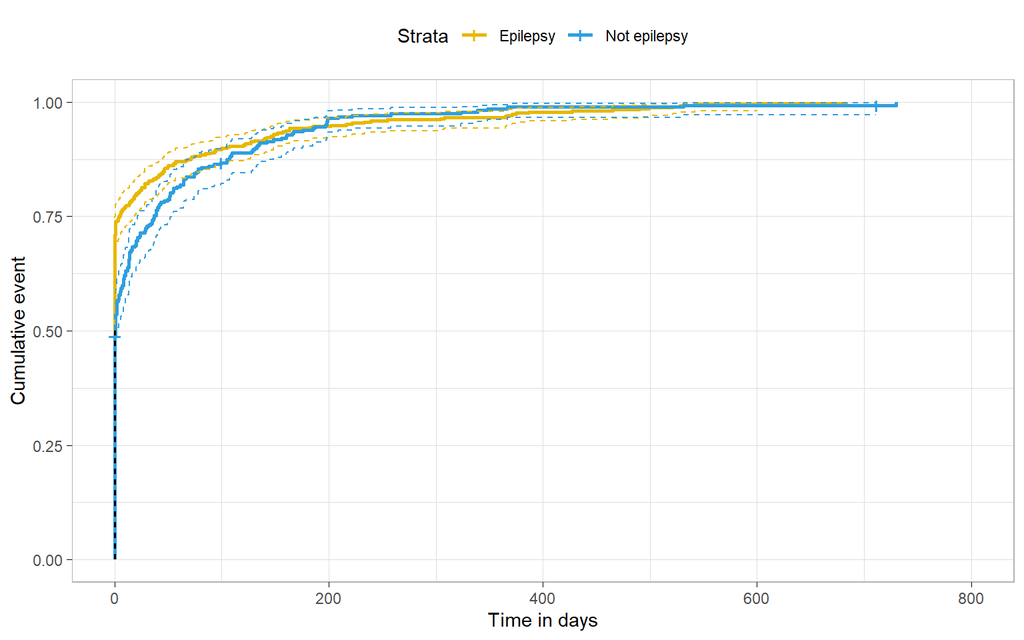

```r
# Evolution of the diagnosis --> all patients
delay_dx_all <- data_full_cleaned%>%
  filter(!is.na(date.1st.cs.su),!is.na(date.dx.final))%>%
  mutate(delay.1st_epi_dx_fin = as_date(date.dx.final) - as_date(date.1st.cs.su))%>%
  filter(delay.1st_epi_dx_fin >= 0)%>%
  summarise(MEAN = round(mean(delay.1st_epi_dx_fin, na.rm = T),2),
            SD = round(sd(delay.1st_epi_dx_fin, na.rm = T),2))

# Evolution of the diagnosis --> epi patients
delay_dx_epi <- data_full_cleaned%>%
  filter(dx.event == "Epilepsy")%>%
  filter(!is.na(date.1st.cs.su),!is.na(date.dx.final))%>%
  mutate(delay.1st_epi_dx_fin = as_date(date.dx.final) - as_date(date.1st.cs.su))%>%
  filter(delay.1st_epi_dx_fin >= 0)%>%
  summarise(MEAN = round(mean(delay.1st_epi_dx_fin, na.rm = T),2),
            SD = round(sd(delay.1st_epi_dx_fin, na.rm = T),2))

# Evolution of the diagnosis --> non epi patients
delay_dx_non_epi <- data_full_cleaned%>%
  filter(dx.event != "Epilepsy" | is.na(dx.event))%>%
  filter(!is.na(date.1st.cs.su),!is.na(date.dx.final))%>%
  mutate(delay.1st_epi_dx_fin = as_date(date.dx.final) - as_date(date.1st.cs.su))%>%
  filter(delay.1st_epi_dx_fin >= 0)%>%
  mutate(dx_first_consult = ifelse(delay.1st_epi_dx_fin == 0, "first_cs", "later"))%>%
  summarise(MEAN = round(mean(delay.1st_epi_dx_fin, na.rm = T),2),
            SD = round(sd(delay.1st_epi_dx_fin, na.rm = T),2))

# Survival analysis investigating the differences in delay to reach the final diagnosis between epileptic and non-epileptic patients.

data_surv <- data_full_cleaned%>%
  select(code.pat, date.1st.cs.su, date.dx.final, dx.event, n.tot.recidives, motif_relapse, detail_relapse)%>%
  filter(!is.na(date.1st.cs.su), !is.na(date.dx.final))%>%
  mutate(date.1st.cs.su = as_date(date.1st.cs.su),
         date.dx.final  = as_date(date.dx.final),
         censored = ifelse(is.na(dx.event) | dx.event == "Unknown", "censored", "diagnosed"),
         dx.dicho = ifelse(dx.event == "Epilepsy", "epilepsy", "other"),
         delay_dx_final = date.dx.final-date.1st.cs.su)%>%
  filter(delay_dx_final >= 0)%>%
  select(-date.dx.final, -date.1st.cs.su, -dx.event)%>%
  mutate(detail_relapse = ifelse(is.na(detail_relapse), "other", detail_relapse),
         relapses = case_when(n.tot.recidives == 0 ~ "no relapse",
                              detail_relapse == "ttt ok et bonne compliance" | detail_relapse == "pas de ttt" | detail_relapse == "ttt ok taux infra ou ttt inadequat" ~ "relapse",
                              dx.dicho == "epilepsy" & n.tot.recidives > 0 & detail_relapse != "ttt ok et bonne compliance" ~ "no relapse",
                              TRUE ~ "relapse"))%>%
  select(-n.tot.recidives, -motif_relapse, -detail_relapse)%>%
  mutate(censored = as.factor(censored),
         dx.dicho = as.factor(dx.dicho),
         relapses = as.factor(relapses),
         delay_dx_final = as.numeric(delay_dx_final))%>%
  mutate(censored = as.numeric(censored),
         dx.dicho = as.numeric(dx.dicho),
         relapses = as.numeric(relapses))%>%
  filter(delay_dx_final <= 730)

# Fitting of the model
fit <- survfit(Surv(delay_dx_final, censored) ~ dx.dicho, data = data_surv)


# Plot
ggsurvplot(
  fit,                     # survfit object with calculated statistics.
  pval = FALSE,
  conf.int = TRUE,         # show confidence intervals for
  # point estimaes of survival curves.
  conf.int.style = "step",  # customize style of confidence intervals
  xlab = "Time in days",   # customize X axis label.
  ggtheme = theme_light(), # customize plot and risk table with a theme.
  # in legend of risk table.
  ncensor.plot = FALSE,      # plot the number of censored subjects at time t
  surv.median.line = "hv",  # add the median survival pointer.
  legend.labs =
    c("Epilepsy", "Not epilepsy"),    # change legend labels.
  palette =
    c("#E7B800", "#2E9FDF"), # custom color palettes.
  fun = "event"
  )
```

```r
# Cox model
cox_model <- coxph(Surv(delay_dx_final, censored) ~ dx.dicho + relapses, data_surv)
results_survival <- summary(cox_model)

results_survival <- round_df(results_survival$coefficients,digits = 3)

# Assumptions of the Cox model
test.ph <- cox.zph(cox_model)
test.ph # Assumption violated !!!! HOW TO FIX IT ?
```

```
##           chisq df       p
## dx.dicho 24.661  1 6.8e-07
## relapses  0.254  1    0.61
## GLOBAL   24.706  2 4.3e-06
```

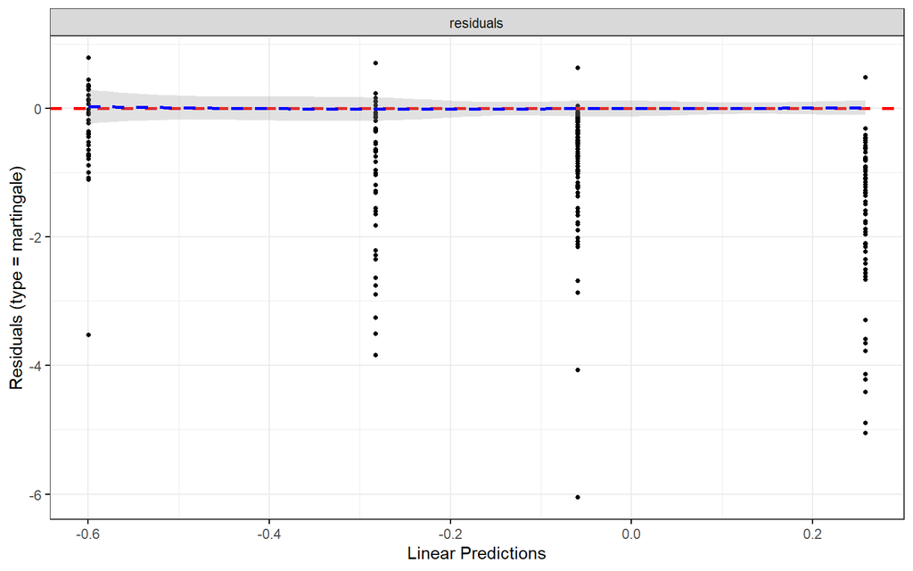

```r
# Influential observations
ggcoxdiagnostics(cox_model, type = , linear.predictions = TRUE)
```

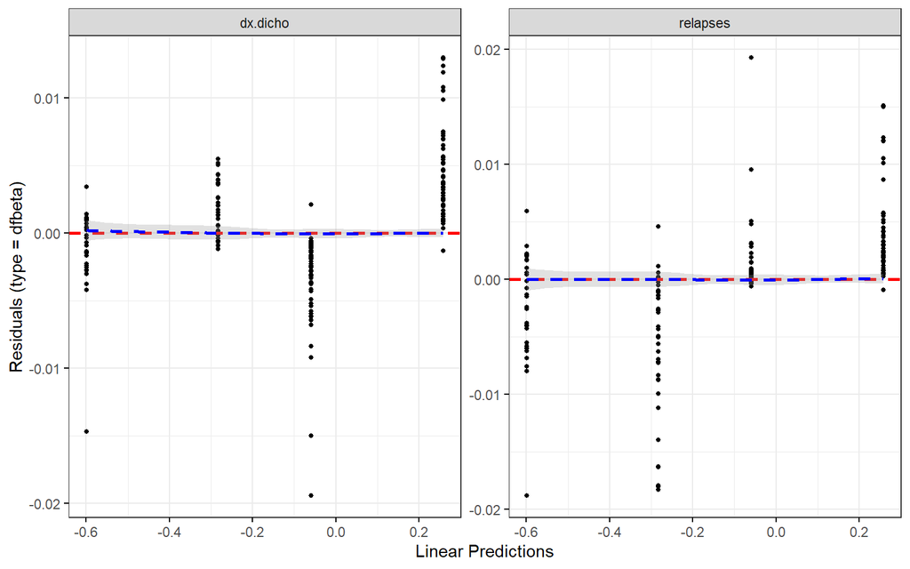

```r
ggcoxdiagnostics(cox_model, type = "dfbeta", linear.predictions = TRUE) # OK --> magnitudes of the dfbetas
```

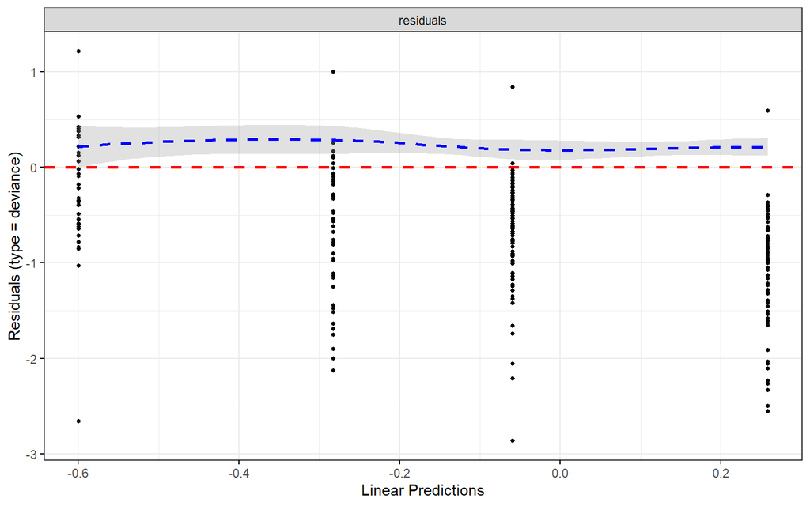

```r
ggcoxdiagnostics(cox_model, type = "deviance", linear.predictions = TRUE)
```

```r
#Impact of delay until the patients recieve their final diagnosis and the relapses


data_relapse_epi <- data_full_cleaned%>%
  select(code.pat, dx.event, dx.epi, type.epi.final, n.tot.recidives, motif_relapse, detail_relapse, date.1st.cs.su, date.dx.final)%>%
  mutate(dx.dicho = ifelse(dx.event != "Epilepsy" | is.na(dx.event), "Non epileptic", "Epileptic"),
         relapses = case_when(n.tot.recidives == 0 ~ "No relapse",
                              dx.dicho == "Non epileptic" & n.tot.recidives > 0 ~ "Relapse",
                              detail_relapse == "pas de ttt" ~ "Relapse",
                              detail_relapse == "ttt ok et bonne compliance" ~ "Relapse",
                              detail_relapse == "Probleme de compliance" ~ "Relapse",
                              detail_relapse == "ttt ok taux infra ou ttt inadequat" ~ "Relapse",
                              motif_relapse == "pas de recidives trouvees" ~ "No relapse",
                              TRUE ~ "No relapse"),
         date.dx.final = as_date(date.dx.final),
         date.1st.cs.su = as_date(date.1st.cs.su),
         delay_dx = date.dx.final - date.1st.cs.su)%>%
  filter(dx.event == "Epilepsy",
         delay_dx != is.na(delay_dx),
         delay_dx >= 0,
         delay_dx < 730)

median_delay_epi <- median(data_relapse_epi$delay_dx)

data_chi_epi <- data_relapse_epi%>%
      mutate(delay_dicho = ifelse(delay_dx < median_delay_epi, "short", "long"))%>%
      select(code.pat, relapses, delay_dicho)%>%
  group_by(relapses, delay_dicho)%>%
  summarise(N = n())%>%
  spread(key = delay_dicho, value = N)
data_chi_epi <- as.data.frame(data_chi_epi[,2:3])

chi_epi <- chisq.test(data_chi_epi) # p-value = 0.2354


# Same but taking all patients together

data_relapse_all <- data_full_cleaned%>%
  select(code.pat, dx.event, dx.epi, type.epi.final, n.tot.recidives, motif_relapse, detail_relapse, date.1st.cs.su, date.dx.final)%>%
  mutate(dx.dicho = ifelse(dx.event != "Epilepsy" | is.na(dx.event), "Non epileptic", "Epileptic"),
         relapses = case_when(n.tot.recidives == 0 ~ "No relapse",
                              dx.dicho == "Non epileptic" & n.tot.recidives > 0 ~ "Relapse",
                              detail_relapse == "pas de ttt" ~ "Relapse",
                              detail_relapse == "ttt ok et bonne compliance" ~ "Relapse",
                              detail_relapse == "Probleme de compliance" ~ "Relapse",
                              detail_relapse == "ttt ok taux infra ou ttt inadequat" ~ "Relapse",
                              motif_relapse == "pas de recidives trouvees" ~ "No relapse",
                              TRUE ~ "No relapse"),
         date.dx.final = as_date(date.dx.final),
         date.1st.cs.su = as_date(date.1st.cs.su),
         delay_dx = date.dx.final - date.1st.cs.su)%>%
  filter(delay_dx != is.na(delay_dx),
         delay_dx >= 0,
         delay_dx < 730)

median_delay_all <- median(data_relapse_all$delay_dx)

data_chi_all <- data_relapse_all%>%
  mutate(delay_dicho = ifelse(delay_dx < median_delay_all, "short", "long"))%>%
  select(code.pat, relapses, delay_dicho)%>%
  group_by(relapses, delay_dicho)%>%
  summarise(N = n())%>%
  spread(key = delay_dicho, value = N)
data_chi_all <- as.data.frame(data_chi_all[,2:3])

chi_all <- chisq.test(data_chi_all) # p-value = 0.001249

# Visualization

plot_all <- data_relapse_all%>%
  mutate(delay_dicho = ifelse(delay_dx < median_delay_all, "short", "long"))%>%
  select(code.pat, relapses, delay_dicho)%>%
  group_by(relapses, delay_dicho)%>%
  summarise(N = n())

plot_epi <- data_relapse_epi%>%
  mutate(delay_dicho = ifelse(delay_dx < median_delay_epi, "short", "long"))%>%
  select(code.pat, relapses, delay_dicho)%>%
  group_by(relapses, delay_dicho)%>%
  summarise(N = n())


plot_all_pat <- plot_all%>%
  ggplot(aes(x = delay_dicho, y = N, fill = relapses))+
  geom_bar(stat = "identity", alpha = 0.8)+
  scale_fill_brewer(palette = "Greens")+
  theme_minimal()+
  labs(x = "Delay first seizure - final diagnosis", title = "All patients", fill = "Relapses")+
  coord_cartesian(ylim = c(0,135))

plot_epi_pat <- plot_epi%>%
  ggplot(aes(x = delay_dicho, y = N, fill = relapses))+
  geom_bar(stat = "identity", alpha = 0.8)+
  scale_fill_brewer(palette = "Reds")+
  theme_minimal()+
  labs(x = "Delay first seizure - final diagnosis", title = "Epileptic patients", fill = "Relapses")+
  coord_cartesian(ylim = c(0,135))

fig_delay_dx <- ggarrange(plot_all_pat, plot_epi_pat)


# Impact of the treatment delay
# epi

data_relapse_epi_ttt <- data_full_cleaned%>%
  select(code.pat, dx.event, dx.epi, type.epi.final, n.tot.recidives, motif_relapse, detail_relapse, date.1st.cs.su, date.debut.tt)%>%
  mutate(dx.dicho = ifelse(dx.event != "Epilepsy" | is.na(dx.event), "Non epileptic", "Epileptic"),
         relapses = case_when(n.tot.recidives == 0 ~ "No relapse",
                              dx.dicho == "Non epileptic" & n.tot.recidives > 0 ~ "Relapse",
                              detail_relapse == "pas de ttt" ~ "Relapse",
                              detail_relapse == "ttt ok et bonne compliance" ~ "Relapse",
                              detail_relapse == "Probleme de compliance" ~ "Relapse",
                              detail_relapse == "ttt ok taux infra ou ttt inadequat" ~ "Relapse",
                              motif_relapse == "pas de recidives trouvees" ~ "No relapse",
                              TRUE ~ "No relapse"),
         date.debut.tt = as_date(date.debut.tt),
         date.1st.cs.su = as_date(date.1st.cs.su),
         delay_tt = date.debut.tt - date.1st.cs.su)%>%
  filter(dx.event == "Epilepsy",
         delay_tt != is.na(delay_tt),
         delay_tt >= 0,
         delay_tt < 730)

median_delay_epi_tt <- median(data_relapse_epi_ttt$delay_tt)

data_chi_epi_tt <- data_relapse_epi_ttt%>%
      mutate(delay_dicho = ifelse(delay_tt < median_delay_epi_tt, "short", "long"))%>%
      select(code.pat, relapses, delay_dicho)%>%
  group_by(relapses, delay_dicho)%>%
  summarise(N = n())%>%
  spread(key = delay_dicho, value = N)
data_chi_epi_tt <- as.data.frame(data_chi_epi_tt[,2:3])

chi_epi_tt <- chisq.test(data_chi_epi_tt) #  p-value = 0.07186


# Vizualisation treatment

# plot_ttt_epi <- data_relapse_epi_ttt%>%
#       mutate(delay_dicho = ifelse(delay_tt < median_delay_epi_tt, "short", "long"))%>%
#       select(code.pat, relapses, delay_dicho)%>%
#   group_by(relapses, delay_dicho)%>%
#   summarise(N = n())
#
# plot_ttt_epi%>%
#   ggplot(aes(x = delay_dicho, y = N, fill = relapses))+
#   geom_bar(stat = "identity")+
#   scale_fill_brewer(palette = "Blues")+
#   theme_minimal()+
#   labs(x = "Delay first seizure - treatment instauration", title = "Epileptic patients", fill = "Relapses")
```

## Epileptic origin

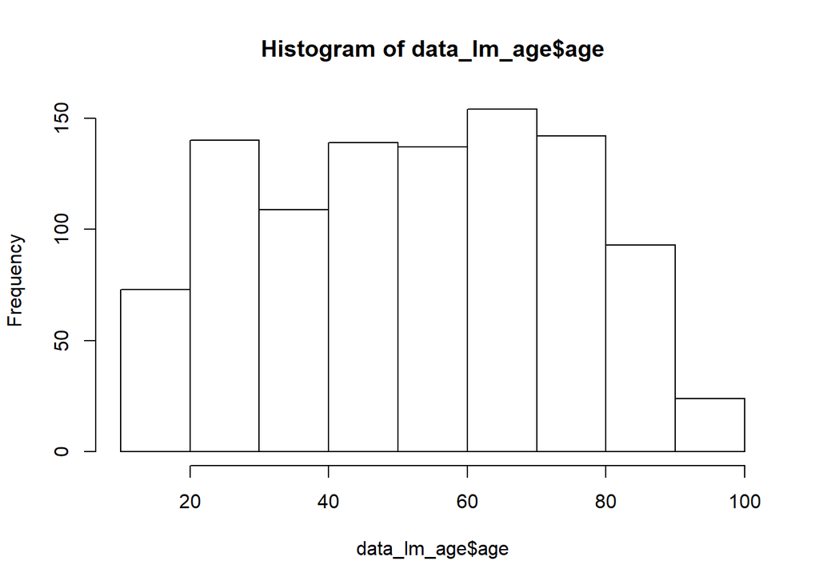

```r
# Chi2 frequency event sleep between epilepsy and non-epilepsy patients
data_chi <- data_full_cleaned%>%select(dx.general, veille.sommeil)%>%
  filter(veille.sommeil != "non documente")%>%
  mutate(dx.general = ifelse(dx.general == "Epileptic seizure", "epileptic seizure", "not epileptic event"))%>%
  group_by(dx.general, veille.sommeil)%>%
  summarise(N = n())%>%
  spread(key = veille.sommeil, N)

data_chi <- as.data.frame(data_chi)
row.names(data_chi) <- data_chi$dx_cat
data_chi <- data_chi[,2:3]

chi_sleep_wake <- chisq.test(data_chi)

# seizure occuring in sleep

sz_sleep <- data_full_cleaned%>%
  filter(veille.sommeil == "sommeil")%>%
  filter(dx.general == "Epileptic seizure") %>%
  summarise(N = n())

sz_sleep_epi <- data_full_cleaned%>%
  filter(veille.sommeil == "sommeil")%>%
  filter(!is.na(code.pat))%>%
  filter(dx.general == "Epileptic seizure") %>%
  filter(dx.event == "Epilepsy")%>%
  summarise(N = n())

# N per epilepsy types
N_epi_dx <- data_full_cleaned%>%
  group_by(dx.epi, type.epi.final)%>%
  summarise(N = n(),
            mean_age = mean(age, na.rm = T),
            sd_age = sd(age, na.rm = T))

tot_epi_disease <- nrow(data_full_cleaned%>%filter(dx.event == "Epilepsy"))

# % and N patients "operated" --> only the tumoral patients

N_pat_tumor <- data_full_cleaned%>%
  filter(type.epi.final == "lesionnelle")%>%
  filter(les.CT == "tumoral" | les.IRM == "tumoral")%>%
  summarise(N = n())

# post_hocs on the lm ANOVA investigating age differences among diagnoses

# ANOVA on age:


data_lm_age <- data_full_cleaned%>%
  mutate(more_1_event = ifelse(SBB.1 > 1, "many", "one"))%>%
  mutate(dx_paste = ifelse(dx.event == "Epilepsy", paste(dx.event, type.epi.final),dx.event))%>%
  select(code.pat, age, dx.event, dx.epi,  more_1_event, dx_paste, genre, les.epi)

hist(data_lm_age$age)
```

```r
model_age_paste <- lm(age ~  dx_paste + more_1_event + genre + les.epi, data = data_lm_age)
vif(model_age_paste)
```

```
##                  GVIF Df GVIF^(1/(2*Df))
## dx_paste     2.738804  9        1.057570
## more_1_event 1.030551  1        1.015160
## genre        1.031529  1        1.015642
## les.epi      2.626659  4        1.128302
```

```r
anova(model_age_paste)
```

```
## Analysis of Variance Table
##
## Response: age
##               Df Sum Sq Mean Sq F value    Pr(>F)
## dx_paste       9  70209  7801.0 20.4964 < 2.2e-16 ***
## more_1_event   1    434   433.9  1.1401  0.285921
## genre          1   3598  3598.3  9.4542  0.002169 **
## les.epi        4  17643  4410.8 11.5891 3.489e-09 ***
## Residuals    918 349395   380.6
## ---
## Signif. codes:  0 '***' 0.001 '**' 0.01 '*' 0.05 '.' 0.1 ' ' 1
```

```r
post_hocs_age <- emmeans(model_age_paste, list(pairwise ~ dx_paste), adjust = "tukey")
post_hocs_age <- as.data.frame(post_hocs_age$`pairwise differences of dx_paste`)
post_hocs_age <- report_results(post_hocs_age, method = "emmeans")

res_mod_age <- report_results(model_age_paste, "mainef_anova")
```

If the event occurred during sleep, a chi-squared test showed that it was more likely to be of epileptic origin (X2 = 15.07; p<0.001). Seizures occurred during sleep in 13.89% (N = 66/475) of the cases, and 78.79% (N = 52/66) of these patients had later confirmed epilepsy.

```r
dx_epi <- data_full_cleaned%>%group_by(dx.epi)%>%summarise(N = n())
N_epi_dx <- data_full_cleaned%>%group_by(dx.event)%>%summarise(N = n())%>%filter(dx.event == "Epilepsy")

# % and N patients "operated" --> only the tumoral patients

N_pat_tumor <- data_full_cleaned%>%
  filter(type.epi.final == "lesionnelle")%>%
  filter(les.CT == "tumoral" | les.IRM == "tumoral")%>%
  summarise(N = n())

# N per epilepsy types
N_epi_dx <- data_full_cleaned%>%
  group_by(dx.epi, type.epi.final)%>%
  summarise(N = n(),
            mean_age = mean(age, na.rm = T),
            sd_age = sd(age, na.rm = T))
```

In 444/1011 (43.92%) the epilepsy was of focal origin, i.e. 93.47% (444/475) of all epilepsy patients. Among the epileptic patients, 137/1011 (13.55%) were diagnosed with a brain tumor and were operated. Non-lesional focal epilepsy affected 60 patients (5.93%).

```r
# Epileptic abnormalities on the EEG

N_epi_spikes <- nrow(data_full_cleaned%>%
  filter(dx.event == "Epilepsy")%>%
  filter(EEG.result_resume == "pointes" |
         EEG.result_resume == "pointes+slow"))


N_epi_EEG <- nrow(data_full_cleaned%>%
  filter(dx.event == "Epilepsy")%>%
  filter(res.1st.EEG != "aucun" ,
         res.1st.EEG != "aucun mais propose"))


N_epi_abnormal <- nrow(data_full_cleaned%>%
                         filter(dx.event == "Epilepsy")%>%
                         filter(res.1st.EEG == "anormal"))

N_epi_abnormal_LT <- nrow(data_full_cleaned%>%
                         filter(dx.event == "Epilepsy")%>%
                         filter(res.lt.EEG == "anormal"))

N_LT_EEG_epi <- nrow(data_full_cleaned%>%
  filter(res.lt.EEG != "aucun" & res.lt.EEG != "aucun mais propose")%>%
    filter(dx.event == "Epilepsy"))

# Non-epileptic abnormalities on the EEG

N_non_epi_abn_EEG <- nrow(data_full_cleaned%>%
       filter(!is.na(code.pat))%>%
       filter(dx.event == "Epilepsy")%>%
       filter(EEG.result_resume == "slow"))


# Normal EEG among epileptic patients

N_epi_norm_EEG <- nrow(data_full_cleaned%>%
       filter(!is.na(code.pat))%>%
       filter(dx.event == "Epilepsy")%>%
       filter(res.1st.EEG == "normal"))


# Delay EEG

EEG_24 <- nrow(data_full_cleaned%>%
  mutate(eeg_delay = date.1st.EEG - date.1st.cs.su)%>%
  filter(eeg_delay < 2)%>%
  select(EEG.result_resume, eeg_delay, dx.final, type.epi.final))

EEG_24_48 <- nrow(data_full_cleaned%>%
  mutate(eeg_delay = date.1st.EEG - date.1st.cs.su)%>%
  filter(eeg_delay >= 2 & eeg_delay < 3)%>%
  select(EEG.result_resume, eeg_delay, dx.final, type.epi.final))

EEG_48_72 <- nrow(data_full_cleaned%>%
  mutate(eeg_delay = date.1st.EEG - date.1st.cs.su)%>%
  filter(eeg_delay >= 3 & eeg_delay < 4)%>%
  select(EEG.result_resume, eeg_delay, dx.final, type.epi.final))

EEG_more_72 <- nrow(data_full_cleaned%>%
  mutate(eeg_delay = date.1st.EEG - date.1st.cs.su)%>%
  filter(eeg_delay >= 4)%>%
  select(EEG.result_resume, eeg_delay, dx.final, type.epi.final))

N_tot_EEG_time <- nrow(data_full_cleaned[!is.na(data_full_cleaned$date.1st.cs.su) & !is.na(data_full_cleaned$date.1st.EEG),])

# Chi squares efficacy EEG delay all patients
data_chi <- data_full_cleaned%>%
  mutate(spikes.dicho = ifelse(EEG.result_resume == "pointes" | EEG.result_resume == "pointes+slow", "pointes", "pas_pointes"),
         spikes.dicho = ifelse(is.na(spikes.dicho), "pas_pointes", spikes.dicho),
         eeg_delay = as.numeric(date.1st.EEG - date.1st.cs.su),
         cat_delay = case_when(eeg_delay < 2 ~ "24h",
                               eeg_delay > 1 & eeg_delay < 3 ~ "48h",
                               eeg_delay > 2 & eeg_delay <4 ~ "72h",
                               eeg_delay >=4 ~ "+72h"))%>%
           group_by(cat_delay, spikes.dicho)%>%
  summarise(N = n())%>%
  spread(cat_delay, N)


data_chi <- data_chi[,2:ncol(data_chi)]

chi2_EEG_all <- chisq.test(data_chi, simulate.p.value = T)

# Chi squares efficacy EEG delay epileptic patients

data_chi <- data_full_cleaned%>%
  filter(dx.event == "Epilepsy")%>%
  mutate(spikes.dicho = ifelse(EEG.result_resume == "pointes" | EEG.result_resume == "pointes+slow", "pointes", "pas_pointes"),
         spikes.dicho = ifelse(is.na(spikes.dicho), "pas_pointes", spikes.dicho),
         eeg_delay = as.numeric(date.1st.EEG - date.1st.cs.su),
         cat_delay = case_when(eeg_delay < 2 ~ "24h",
                               eeg_delay > 1 & eeg_delay < 3 ~ "48h",
                               eeg_delay > 2 & eeg_delay <4 ~ "72h",
                               eeg_delay >=4 ~ "+72h"))%>%
           group_by(cat_delay, spikes.dicho)%>%
  summarise(N = n())%>%
  spread(cat_delay, N)

data_chi <- data_chi[,2:ncol(data_chi)]

chi2_EEG_epi <- chisq.test(data_chi, simulate.p.value = T)


juv_myo <- 13
grand_mal_awa <- 3
tot_IGE <- nrow(data_full_cleaned%>%filter(dx.epi == "Primary generalized epilepsy"))
non_classifiable <- tot_IGE - juv_myo - grand_mal_awa
```

325 (325/472) patients showed EEG-abnormalities in the routine EEG (spikes or slowing), and 67 (66.34%; 67/101) in the LTM-EEG. One patient without MRI-lesion presented strongly suggestive semiology (post-ictal shoulder luxation) but had only unspecific focal EEG abnormalities.

We diagnosed idiopathic generalized (genetic) epilepsy in 31 patients (3.07% of all patients, M = 26.35; SD = 10.83). The most frequent syndrome was juvenile myoclonic epilepsy (N = 13). The IGE group was significantly younger than the group of patients with focal epilepsy (IGE vs. SE: t(918) = -5.33; p <0.001; IGE vs. NLE: t(918) = -4.05; p = 0.002).

```r
N_epi_non_dx <- data_full_cleaned%>%
  group_by(dx.event)%>%
  summarise(N = n(),
            mean_age = round(mean(age, na.rm = T),2),
            sd_age = round(sd(age, na.rm = T),2))

# N men in the PNES group
post_hoc_gender_PNES <- emmeans(model_age_paste, list(pairwise ~ genre|dx_paste), adjust = "tukey")
post_hoc_gender_PNES <- post_hoc_gender_PNES$`pairwise differences of genre | dx_paste`
post_hoc_gender_PNES <- as.data.frame(post_hoc_gender_PNES)
post_hoc_gender_PNES <- report_results(post_hoc_gender_PNES, "emmeans")

temp <- data_full_cleaned%>%
  filter(dx.event == "Psychogenic non epileptic seizure")%>%
  group_by(genre)%>%
  summarise(N = n())

N_H_psy <- temp$N[temp$genre == "H"]
N_psy <- sum(temp$N)

# ATCD psy
atcd_gender<- data_full_cleaned%>%
  group_by(genre, ATCD_specific)%>%
  summarise(N = n())%>%
  mutate( ATCD_specific = case_when(ATCD_specific == 'aucun' ~ 'No comorbidities',
                                    ATCD_specific == 'autres' ~ 'Other',
                                    ATCD_specific == 'cardiaque' ~ 'Cardiac',
                                    ATCD_specific == 'neurologique' ~ 'Neurologic',
                                    ATCD_specific == 'psychiatrique' ~ 'Psychiatric'))%>%
  filter(!is.na(ATCD_specific))%>%
  mutate(PCT = pct.fun(N, sum_history))%>%
  rename(`Relevant events in medical history` = ATCD_specific)

# age cardiac and cardiovascular

dx_event_desc <- data_full_cleaned%>%
  group_by(dx.event, dx.epi)%>%
  summarise(N = n(), age.pat = mean(age), sd = sd(age))

ATCD <- data_full_cleaned%>%
  group_by(ATCD_specific)%>%
  summarise(N = n(),
            AGE = mean(age, na.rm = T),
            SD_AGE = sd(age, na.rm = T))%>%
  mutate(ATCD_specific = case_when(ATCD_specific == 'aucun' ~ 'No comorbidities',
                                    ATCD_specific == 'autres' ~ 'Other',
                                    ATCD_specific == 'cardiaque' ~ 'Cardiac',
                                    ATCD_specific == 'neurologique' ~ 'Neurologic',
                                    ATCD_specific == 'psychiatrique' ~ 'Psychiatric'))%>%
  filter(!is.na(ATCD_specific))%>%
  mutate(PCT = pct.fun_n(N,sum(table_2$N)))
```

## Non-epileptic origin

Even though women were significantly more likely to have psychogenic non-epileptic seizures compared to other non-epileptic diagnoses ( t(918) = 2.97; p = 0.003), the diagnosis was not rare in men (N = 27/67; 40.3%).As shown in Table 2, psychiatric history was positive in 53 patients over 776, among whose 52.83% were women and 47.17% were males.

```r
N_plus60_vaso <- nrow(data_full_cleaned%>%
  filter(dx.event == "Vaso-vagal and orthostatic syncopes")%>%
  filter(age > 60))
```

In 6.53% (66/ 1011) the final diagnosis was vasovagal syncope. Long post-syncope confusion, the notion of clonic or asymmetric movements, or comorbidities affecting the CNS required in-depth investigations. 27.27% affected patients older than 60.

```r
table_3 <- data_full_cleaned%>%
  filter(dx.event == "Cardiovascular")%>%
  group_by(type.cardiovasculaire)%>%
  summarise(N = n())%>%
  mutate(type.cardiovasculaire = case_when(type.cardiovasculaire == "ACR" ~ "Cardiac arrest",
                   type.cardiovasculaire == "AIT" ~ "Transient ischemic attack",
                   type.cardiovasculaire == "AVC" ~ "Stroke",
                   type.cardiovasculaire == "multifactoriel" ~ "Multifactorial",
                   type.cardiovasculaire == "symptomes post-AVC" ~ "Post-stroke symptoms",
                   type.cardiovasculaire == "syncope" ~ "Syncope"))
```

| type.cardiovasculaire | N |
| --- | --- |
| Transient ischemic attack | 22 |
| Stroke | 13 |
| Multifactorial | 1 |
| Syncope | 20 |

## Mortality

```r
# Proportion of patients who deceased in the 2 years follow-up

data_dead <- data_full_cleaned%>%
  dplyr::mutate(alive = ifelse(!is.na(date.deces) | !is.na(cause.deces), "dead", "alive"),
                dx.dicho = ifelse(dx.event == "Epilepsy", "epi", "non-epi"),
                dx.dicho = ifelse(is.na(dx.dicho), "non-epi", dx.dicho))%>%
  dplyr::group_by(alive)%>%
  dplyr::summarise(N = n(),
            mean_age = round(mean(age),2),
            sd_age = round(sd(age),2))


data_dead_HF <- data_full_cleaned%>%
  dplyr::mutate(alive = ifelse(!is.na(date.deces) | !is.na(cause.deces), "dead", "alive"),
                dx.dicho = ifelse(dx.event == "Epilepsy", "epi", "non-epi"),
                dx.dicho = ifelse(is.na(dx.dicho), "non-epi", dx.dicho))%>%
  dplyr::group_by(alive, genre)%>%
  dplyr::summarise(N = n(),
            mean_age = round(mean(age),2),
            sd_age = round(sd(age),2))

# Difference in proportion between epileptic and non-epileptic patients regarding the mortality rate

datachi <- data_full_cleaned%>%
  dplyr::mutate(alive = ifelse(!is.na(date.deces) | !is.na(cause.deces), "dead", "alive"),
                dx.dicho = ifelse(dx.event != "Epilepsy" | is.na(dx.event), "non-epi", "epi"))%>%
  dplyr::group_by(dx.dicho,alive)%>%
  summarise(N = n())%>%
  spread(key = alive, value = N)

datachi <- as.data.frame(datachi)
rownames(datachi) <- datachi$dx.dicho
datachi$dx.dicho <- NULL

chi_dead <- chisq.test(datachi)
```

Among the entire sample, 114 patients deceased during the two year follow-up (11.28%; mean age = 68.15; 51 females and 63 males). In the epileptic group (N = 82/475; 17.26%), this proportion is significantly larger than in the non-epileptic group (N = 32/536; 5.97%; X2 = 30.98; p<0.001), which is mainly due to patients with epilepsy and dementia or brain tumors. Two epileptic patients died from other causes (one of them from cardiac origin and the other one from severe hypernatremia and infection) and for six patients the cause of the death remained unclear. None of the patients experienced death related directly to an epileptic seizure.

## Diagnostic tools

### MRI-CT

```r
N_les <- data_full_cleaned%>%
  filter(res.IRM != "aucun", res.IRM != "aucun mais propose")%>%
  group_by(les.epi)%>%
  summarise(N = n())

N_normal <- N_les$N[N_les$les.epi == "normal"]+N_les$N[N_les$les.epi == "lesion non epileptogene"]

post_hoc_les <- emmeans(model_age, list(pairwise ~ les.epi), adjust = "tukey")
post_hoc_les <- as.data.frame(post_hoc_les$`pairwise differences of les.epi`)
post_hoc_les <- report_emmeans(post_hoc_les)

# Among epileptic patients

N_les_epi <- data_full_cleaned%>%
  filter(dx.event == "Epilepsy")%>%
  filter(res.IRM != "aucun", res.IRM != "aucun mais propose")%>%
  group_by(les.epi)%>%
  summarise(N = n())

N_normal_epi <- N_les_epi$N[N_les_epi$les.epi == "normal"]+N_les_epi$N[N_les_epi$les.epi == "lesion non epileptogene"]
```

### Routine EEG

```r
N_EEG <- nrow(data_full_cleaned%>%
  filter(EEG.result_resume == "pointes"))+nrow(data_full_cleaned%>%
  filter(EEG.result_resume == "slow"))+nrow(data_full_cleaned%>%
  filter(res.1st.EEG == "normal"))+nrow(data_full_cleaned%>%
  filter(EEG.result_resume == "pointes+slow"))

N_EEG_spikes <-nrow(data_full_cleaned%>%
  filter(EEG.result_resume == "pointes" |
         EEG.result_resume == "pointes+slow"))

N_EEG_slow <- nrow(data_full_cleaned%>%
  filter(EEG.result_resume == "slow"))

N_EEG_normal <- nrow(data_full_cleaned%>%
  filter(res.1st.EEG == "normal"))

# EEG delay

# Epileptic abnormalities on the EEG

N_epi_spikes <- nrow(data_full_cleaned%>%
  filter(!is.na(code.pat))%>%
  filter(dx.event == "Epilepsy")%>%
  filter(EEG.result_resume == "pointes" |
         EEG.result_resume == "pointes+slow"))


N_epi_EEG <- nrow(data_full_cleaned%>%
  filter(!is.na(code.pat))%>%
  filter(dx.event == "Epilepsy")%>%
  filter(res.1st.EEG != "aucun" ,
         res.1st.EEG != "aucun mais propose"))

# Non-epileptic abnormalities on the EEG

N_non_epi_abn_EEG <- nrow(data_full_cleaned%>%
       filter(!is.na(code.pat))%>%
       filter(dx.event == "Epilepsy")%>%
       filter(EEG.result_resume == "slow"))


# Normal EEG among epileptic patients

N_epi_norm_EEG <- nrow(data_full_cleaned%>%
       filter(!is.na(code.pat))%>%
       filter(dx.event == "Epilepsy")%>%
       filter(res.1st.EEG == "normal"))


# Delay EEG

EEG_24 <- nrow(data_full_cleaned%>%
  mutate(eeg_delay = date.1st.EEG - date.1st.cs.su)%>%
  filter(eeg_delay < 2)%>%
  select(EEG.result_resume, eeg_delay, dx.final, type.epi.final))

EEG_24_48 <- nrow(data_full_cleaned%>%
  mutate(eeg_delay = date.1st.EEG - date.1st.cs.su)%>%
  filter(eeg_delay >= 2 & eeg_delay < 3)%>%
  select(EEG.result_resume, eeg_delay, dx.final, type.epi.final))

EEG_48_72 <- nrow(data_full_cleaned%>%
  mutate(eeg_delay = date.1st.EEG - date.1st.cs.su)%>%
  filter(eeg_delay >= 3 & eeg_delay < 4)%>%
  select(EEG.result_resume, eeg_delay, dx.final, type.epi.final))

EEG_more_72 <- nrow(data_full_cleaned%>%
  mutate(eeg_delay = date.1st.EEG - date.1st.cs.su)%>%
  filter(eeg_delay >= 4)%>%
  select(EEG.result_resume, eeg_delay, dx.final, type.epi.final))

N_tot_EEG_time <- nrow(data_full_cleaned[!is.na(data_full_cleaned$date.1st.cs.su) & !is.na(data_full_cleaned$date.1st.EEG),])

# Chi squares efficacy EEG delay all patients
data_chi <- data_full_cleaned%>%
  mutate(spikes.dicho = ifelse(EEG.result_resume == "pointes" | EEG.result_resume == "pointes+slow", "pointes", "pas_pointes"),
         spikes.dicho = ifelse(is.na(spikes.dicho), "pas_pointes", spikes.dicho),
         eeg_delay = as.numeric(date.1st.EEG - date.1st.cs.su),
         cat_delay = case_when(eeg_delay < 2 ~ "24h",
                               eeg_delay > 1 & eeg_delay < 3 ~ "48h",
                               eeg_delay > 2 & eeg_delay <4 ~ "72h",
                               eeg_delay >=4 ~ "+72h"))%>%
           group_by(cat_delay, spikes.dicho)%>%
  summarise(N = n())%>%
  spread(cat_delay, N)

data_chi <- data_chi[,2:ncol(data_chi)]

chi2_EEG_all <- chisq.test(data_chi, simulate.p.value = T)

# Chi squares efficacy EEG delay epileptic patients

data_chi <- data_full_cleaned%>%
  filter(dx.event == "Epilepsy")%>%
  mutate(spikes.dicho = ifelse(EEG.result_resume == "pointes" | EEG.result_resume == "pointes+slow", "pointes", "pas_pointes"),
         spikes.dicho = ifelse(is.na(spikes.dicho), "pas_pointes", spikes.dicho),
         eeg_delay = as.numeric(date.1st.EEG - date.1st.cs.su),
         cat_delay = case_when(eeg_delay < 2 ~ "24h",
                               eeg_delay > 1 & eeg_delay < 3 ~ "48h",
                               eeg_delay > 2 & eeg_delay <4 ~ "72h",
                               eeg_delay >=4 ~ "+72h"))%>%
           group_by(cat_delay, spikes.dicho)%>%
  summarise(N = n())%>%
  spread(cat_delay, N)


data_chi <- data_chi[,2:ncol(data_chi)]

chi2_EEG_epi <- chisq.test(data_chi, simulate.p.value = T)
```

997 patients underwent a routine EEG. In 143 patients epileptiform discharges were identified (14.34%), in 315 (31.59%) unspecific abnormalities like slowing, and 539 patients (54.06%) had a completely normal EEG.

While we aimed at carrying out the EEG within 24h, this was not always possible. Among patients in whom timing of the routine EEG could be retrieved (N = 908/997), in 692 (76.21%), the standard EEG was done within 24h. 5.95% (N = 54/908) were realized between 24 and 48h, 2.42% (N = 22/908) between 48h and 72h, and the reminder 15.42% (N = 140/908) after 72h. There was a marginal tendency to pick up epileptiform abnormalities if the EEG was carried out within a short delay (X2 = 8.16; p = 0.082).

```r
temp <- data_full_cleaned%>%filter(dx.event != "Epilepsy" | is.na(dx.event))%>%
  filter(EEG.result_resume == "pointes" | EEG.result_resume == "pointes+slow")%>%
  group_by(dx.general, dx.event, dx.epi)%>%
  summarise(N = n())

N_spikes_not_epi <- nrow(data_full_cleaned%>%
  filter(EEG.result_resume == "pointes" |
           EEG.result_resume == "pointes+slow")%>%
  filter(dx.event != "Epilepsy" & dx.event != "Acute symptomatic seizure" & dx.event != "Unknown")%>%
  select(code.pat, date.1st.cs.su, date.1st.EEG, res.1st.EEG, EEG.result_resume,  date.lt.EEG, res.lt.EEG, EEG.lt.result_resume, dx.final, type.epi.final, type.autre.final))

N_spikes_not_epi_lt_normal <- nrow(data_full_cleaned%>%
  filter(EEG.result_resume == "pointes" |
           EEG.result_resume == "pointes+slow")%>%
  filter(dx.event != "Epilepsy" & dx.event != "Acute symptomatic seizure" & dx.event != "Unknown")%>%
    filter(res.lt.EEG == "normal")%>%
  select(code.pat, date.1st.cs.su, date.1st.EEG, res.1st.EEG, EEG.result_resume,  date.lt.EEG, res.lt.EEG, EEG.lt.result_resume, dx.final, type.epi.final, type.autre.final))

rest_non_epi_spikes <- N_spikes_not_epi-N_spikes_not_epi_lt_normal


data_full_cleaned%>%
  filter(EEG.result_resume == "pointes" |
           EEG.result_resume == "pointes+slow")%>%
  filter(dx.event != "Epilepsy" & dx.event != "Acute symptomatic seizure" & dx.event != "Unknown")%>%
    filter(res.lt.EEG == "anormal")%>%
  select(code.pat, date.1st.cs.su, date.1st.EEG, res.1st.EEG, EEG.result_resume,  date.lt.EEG, res.lt.EEG, EEG.lt.result_resume, dx.final, type.epi.final, type.autre.final)
```

```
## # A tibble: 1 x 11
##   code.pat date.1st.cs.su date.1st.EEG res.1st.EEG EEG.result_resu~ date.lt.EEG
##   <chr>    <date>         <date>       <chr>       <chr>            <date>
## 1 CL_LU_18 2011-09-18     2011-09-19   anormal     pointes          2011-12-20
## # ... with 5 more variables: res.lt.EEG <chr>, EEG.lt.result_resume <chr>,
## #   dx.final <chr>, type.epi.final <chr>, type.autre.final <chr>
```

```r
not_epi_spikes <- data_full_cleaned%>%
  filter(dx.event != "Epilepsy")%>%
  filter(EEG.result_resume == "pointes" | EEG.result_resume == "pointes+slow")%>%
  filter(dx.event != "Acute symptomatic seizure", dx.event != "Unknown")%>%
  select(code.pat, pointes.lt.EEG, res.lt.EEG, EEG.lt.result_resume, dx.event)%>%
  mutate(state = case_when(res.lt.EEG == "normal" ~ "normal", ))
```

EEG patterns suggestive of epileptiform abnormalities were found in five patients out of 536 presenting with non-epileptic events corresponding to 0.93% of false positive results. For two of them, the LT EEG was normal and the epileptogenic abnormality (sharper slow waves in all cases), seen in the routine EEG, could not be confirmed. In two other cases, no long-term EEG was proposed or patient refused (N = 1) or not proposed to the patient (N = 1), but the observed epileptiform discharges location was not concordant with the semiology of the event, leading to the exclusion of the diagnosis of epilepsy despite the observed electrical abnormalities. Finally, in one case, only a slowing was highlighted but no spikes were visible on the LTM-EEG.

```r
N_LT_EEG <- nrow(data_full_cleaned%>%
  filter(res.lt.EEG != "aucun" & res.lt.EEG != "aucun mais propose"))

N_spikes_LTEEG <- nrow(data_full_cleaned%>%
  filter(res.lt.EEG != "aucun" & res.lt.EEG != "aucun mais propose")%>%
    filter(EEG.lt.result_resume == "pointes" | EEG.lt.result_resume == "pointes+slow"))

N_spikes_LTEEG_epi <- nrow(data_full_cleaned%>%
  filter(res.lt.EEG != "aucun" & res.lt.EEG != "aucun mais propose")%>%
    filter(EEG.lt.result_resume == "pointes" | EEG.lt.result_resume == "pointes+slow")%>%
    filter(dx.event == "Epilepsy"))

spikes_non_epi <- data_full_cleaned%>%
  filter(EEG.lt.result_resume == "pointes" | EEG.lt.result_resume == "pointes+slow")%>%
  filter(dx.event != "Epilepsy")%>%
  group_by(dx.event)%>%
  summarise(N = n())

N_LT_EEG_norm_std <- nrow(data_full_cleaned%>%
       filter(!is.na(code.pat))%>%
       filter(dx.event == "Epilepsy")%>%
       filter(EEG.result_resume == "slow" | res.1st.EEG == "normal")%>%
         filter(res.lt.EEG != "aucun" & res.lt.EEG != "aucun mais propose"))

N_LT_EEG_norm_std_spikes <- nrow(data_full_cleaned%>%
       filter(!is.na(code.pat))%>%
       filter(dx.event == "Epilepsy")%>%
       filter(EEG.result_resume == "slow" | res.1st.EEG == "normal")%>%
         filter(res.lt.EEG != "aucun" & res.lt.EEG != "aucun mais propose")%>%
         filter(EEG.lt.result_resume == "pointes" | EEG.lt.result_resume == "pointes+slow"))

yield_LT_EEG <-pct.fun((N_EEG_spikes/N_EEG), (N_spikes_LTEEG/N_LT_EEG))
```

239 patients underwent LTM-EEG. Overall, 67 patients (28.03%) showed epileptiform discharges, leading to the diagnosis of epilepsy in 59 (88.06%). Among the remaining eight, two of them were diagnosed as acute symptomatic seizures, and for two others, the pathological nature of the anomalies remained uncertain.

Of the patients with epilepsy but normal EEG or non-epileptogenic abnormalities at the standard EEG (N = 350), 77 (22%) underwent LTM-EEG which identified epileptiform discharges in an additional 39 patients (50.65%), which corresponds to a yield of 51.16%.

## Multimodal information

```r
# Patients with all 3 negative exams

N_pat_all_normal <- nrow(data_full_cleaned%>%
  filter(pointes.1st.EEG != "focale" & pointes.1st.EEG != "diffuse" & res.1st.EEG != "aucun" & res.1st.EEG != "aucun mais propose")%>%
   filter(pointes.lt.EEG != "focale" & pointes.lt.EEG != "diffuse" & res.lt.EEG != "aucun" & res.lt.EEG != "aucun mais propose")%>%
  filter(les.epi == "normal" | les.epi == "lesion non epileptogene")%>%
  filter(res.IRM != "aucun" & res.IRM != "aucun mais propose"))

N_pat_all_normal_suspicious_les <- nrow(data_full_cleaned%>%filter(res.1st.EEG != "aucun" & res.1st.EEG != "aucun mais propose")%>%
  filter(EEG.result_resume == "slow" | is.na(EEG.result_resume))%>%
  filter(res.lt.EEG != "aucun" & res.lt.EEG != "aucun mais propose")%>%
  filter(EEG.lt.result_resume == "slow" | is.na(EEG.lt.result_resume))%>%
  filter(res.IRM != "aucun" & res.IRM != "aucun mais propose")%>%
  filter(les.epi != "lesion epileptogene")%>%
  select(pointes.1st.EEG, pointes.lt.EEG, res.IRM, les.epi)%>%
  filter(les.epi == "douteux"))

# N patients epileptic among these patients
N_pat_all_normal_epi <- nrow(data_full_cleaned%>%
  filter(pointes.1st.EEG != "focale" & pointes.1st.EEG != "diffuse" & res.1st.EEG != "aucun" & res.1st.EEG != "aucun mais propose")%>%
  filter(pointes.lt.EEG != "focale" & pointes.lt.EEG != "diffuse" & res.lt.EEG != "aucun" & res.lt.EEG != "aucun mais propose")%>%
  filter(les.epi == "normal" | les.epi == "lesion non epileptogene")%>%
  filter(res.IRM != "aucun" & res.IRM != "aucun mais propose")%>%
  filter(dx.event == "Epilepsy"))

# Same but only with routine EEG and MRI
N_pat_all_normal_epi_lt_mri <- nrow(data_full_cleaned%>%
  filter(res.1st.EEG != "aucun" & res.1st.EEG != "aucun mais propose")%>%
  filter(pointes.lt.EEG != "focale" & pointes.lt.EEG != "diffuse" & res.lt.EEG != "aucun" & res.lt.EEG != "aucun mais propose")%>%
  filter(les.epi == "normal" | les.epi == "lesion non epileptogene")%>%
  filter(res.IRM != "aucun" & res.IRM != "aucun mais propose")%>%
  filter(dx.event == "Epilepsy"))

missed_patients <- nrow(data_full_cleaned%>%
  filter(res.1st.EEG != "normal" | EEG.result_resume == "slow")%>%
  filter(res.IRM != "aucun" & res.IRM != "aucun mais propose")%>%
  filter(les.epi != "lesion epileptogene")%>%
  filter(EEG.lt.result_resume == "pointes" | EEG.lt.result_resume == "pointes+slow"))
```

## Relapses

Among all patients, 245 (24.23%) relapsed. The proportion was significantly higher for epileptic patients (N = 162/475; 34.11%), compared to non epileptic patients (N = 83/536; 15.49%; X2 = 46.54; p<0.001). There was no difference between focal and generalized epilepsy (X2 = 0.18; p = 0.674). However, within the focal epilepsy group, patients with non-lesional epilepsy (N = 32/60 ; 53.33%) are significantly more likely to relapse compared to patients with lesional epilepsy (N = 121/384; 31.51%; X2 = 10; p = 0.002).

Regarding patients with a non-epileptic diagnosis, cardiac patients have the highest relapse rate compared to the other non-epileptic groups (N = 5/17; 29.41%), however, this difference did not reach significance (X2 = 1.62; p = 0.203). Interestingly, we observed 28.57% of relapse in the group of acute symptomatic seizures, which is as high as the focal lesional epilepsy group and the cardiac group, suggesting a review of current driving regulations. See Table 5 for a complete description of the relapse rate per diagnosis.

| dx.event | dx.epi | type.epi.final | No relapse | Relapse | percentage | pct_n |
| --- | --- | --- | --- | --- | --- | --- |
| Acute symptomatic seizure | NA | NA | 30 | 12 | 28.57% | 28.57 |
| Cardiac | NA | NA | 12 | 5 | 29.41% | 29.41 |
| Cardiovascular | NA | NA | 47 | 9 | 16.07% | 16.07 |
| Epilepsy | Focal epilepsy | lesionnelle | 263 | 121 | 31.51% | 31.51 |
| Epilepsy | Focal epilepsy | non lesionnelle | 28 | 32 | 53.33% | 53.33 |
| Epilepsy | Primary generalized epilepsy | generalisee idiopathique | 22 | 9 | 29.03% | 29.03 |
| Other | NA | NA | 124 | 20 | 13.89% | 13.89 |
| Psychogenic non epileptic seizure | NA | NA | 61 | 6 | 8.96% | 8.96 |
| Unknown | NA | indetermine | 57 | 11 | 16.18% | 16.18 |
| Vaso-vagal and orthostatic syncopes | NA | NA | 62 | 4 | 6.06% | 6.06 |
| NA | NA | NA | 60 | 16 | 21.05% | 21.05 |

```r
# Table of the reason of relapse among the epileptic patients
N_epi <- nrow(data_full_cleaned%>%filter(dx.event == "Epilepsy"))

type_relapse_table <- data_full_cleaned%>%
  filter(dx.event == "Epilepsy")%>%
  group_by(detail_relapse)%>%
  summarise(N = n(),
            PCT = pct.fun_n(N, N_epi))%>%
  mutate(detail_relapse = case_when(detail_relapse == "crise provoquee" ~ "Acute symptomatic seizure",
                                    detail_relapse == "pas de ttt" ~ "No treatment",
                                    detail_relapse == "Probleme de compliance" ~ "Compliance problem",
                                    detail_relapse == "ttt ok et bonne compliance" ~ "Adequate treatment and good compliance",
                                    detail_relapse == "ttt ok taux infra ou ttt inadequat" ~ "Infra-therapeutic drug-level or suboptimal treatment ",
                                    is.na(detail_relapse) ~ "no relapse"))

# Acute relapses
N_acute <- 4
OH <- 2
sevr_ttt <- 2
```

Among epileptic patients, we investigated the most likely cause of the relapse following the index event. In 56, another seizure occurred despite an adequate treatment and no compliance problems, suggestive of early onset pharmacoresistent epilepsy (N = 56/475; 11.79%). In 43 patients (9.05%), antiepileptic treatment was refused. In 29, non-compliance was identified as the most likely cause (6.11%). In the remaining patients, relapses occurred while treatment was progressively introduced and thus, due to insufficient drug levels. In four patients with a diagnosis of epilepsy, a second seizure turned out to be of acute symptomatic origin (two with alcohol and two with benzodiazepine withdrawal).

## Predictive models

### Model predicting the diagnosis

```r
data_reg_log <- data_full_cleaned%>%
  mutate(dx.dicho = ifelse(dx.event != "Epilepsy" | is.na(dx.event), "non-epileptic", "epileptic"),
         EEG = case_when(!is.na(EEG.result_resume) ~ EEG.result_resume,
                         res.1st.EEG == "aucun" | res.1st.EEG == "aucun mais propose" ~ "aucun",
                         TRUE ~ "normal"),
         les.epi = ifelse(les.epi == "aucun", NA, les.epi),
         status.neuro = ifelse(status.neuro == "aucun" | status.neuro == "aucun mais propose", NA, status.neuro),
         veille.sommeil = ifelse(veille.sommeil == "non documente", NA, veille.sommeil),
         EEG = ifelse(EEG == "aucun", NA, EEG),
         atcd.famille = ifelse(atcd.famille == "aucun/autre", "aucun", atcd.famille),
         dx.dicho = as.factor(dx.dicho),
         genre = as.factor(genre),
         atcd.famille = as.factor(atcd.famille),
         EEG = as.factor(EEG),
         les.epi = as.factor(les.epi),
         status.neuro = as.factor(status.neuro),
         veille.sommeil = as.factor(veille.sommeil))%>%
  select(code.pat, dx.dicho, age, genre, atcd.famille, EEG, les.epi, status.neuro, veille.sommeil)

mod_log <- glm(dx.dicho ~ age + genre + atcd.famille + EEG + les.epi + status.neuro + veille.sommeil, family = "binomial", data = data_reg_log)

Anova_reg_log <- as.data.frame(Anova(mod_log))
anova_reg_log <- as.data.frame(anova(mod_log))
anova_reg_log <- anova_reg_log[2:nrow(anova_reg_log),]

res_reg_log <- cbind(anova_reg_log, Anova_reg_log)
res_reg_log <- res_reg_log[,-6]
res_reg_log$Predictor <- row.names(res_reg_log)
res_reg_log <- res_reg_log%>%
  arrange(desc(Deviance))%>%
  mutate(Deviance = round(Deviance, 2),
         `Resid. Dev` = round(`Resid. Dev`,2),
         `LR Chisq` = round(`LR Chisq`,2),
         `Pr(>Chisq)` = round(`Pr(>Chisq)`, 3),
         `Pr(>Chisq)` = ifelse(`Pr(>Chisq)` < 0.001, "<0.001", `Pr(>Chisq)`))%>%
  select(Predictor, Df, Deviance, `Resid. Df`, `Resid. Dev`, `LR Chisq`, `Pr(>Chisq)`)

table_6 <- res_reg_log
```

To determine how much each clinical and paraclinical information contribute to the elaboration of the diagnosis, a logistic regression was performed, including as dependent variable the diagnosis (epileptic/not epileptic), and as predictors the patient’s age, its gender, the familial history, results of the standard EEG (spikes/slow/spikes and slow/ normal), the presence of an epileptogenic lesion (normal/uncertain/epileptogenic lesion/non-epileptogenic lesion), the results or the neuro status (normal/abnormal), and if the event happened during wake or sleep. Results (see Table X) show that the presence of an epileptogenic lesion and the results of the EEG predict the best the diagnosis. All the other factors seem to play a role, except for the results of the status neuro and the familial history for which no main effect were highlighted.

| Predictor | Df | Deviance | Resid. Df | Resid. Dev | LR Chisq | Pr(>Chisq) |
| --- | --- | --- | --- | --- | --- | --- |
| les.epi | 3 | 196.32 | 824 | 777.64 | 188.45 | <0.001 |
| EEG | 3 | 170.77 | 827 | 973.97 | 111.21 | <0.001 |
| genre | 1 | 7.48 | 832 | 1145.63 | 4.76 | 0.029 |
| veille.sommeil | 1 | 6.30 | 821 | 768.94 | 6.30 | 0.012 |
| age | 1 | 3.14 | 833 | 1153.11 | 5.77 | 0.016 |
| status.neuro | 2 | 2.41 | 822 | 775.24 | 2.02 | 0.364 |
| atcd.famille | 2 | 0.90 | 830 | 1144.73 | 4.41 | 0.11 |

*Table X: results table of the logistic regression model investigating the effect of each variable on the ability to predict the diagnosis. Factors are arranged by deviance.*

### Estimation of the yield of LTM-EEG over routine EEG

```r
data_LT_over_std <- data_full_cleaned%>%
  mutate(dx.dicho = ifelse(dx.event != "Epilepsy" | is.na(dx.event), "non-epileptic", "epileptic"),
         EEG = case_when(!is.na(EEG.result_resume) ~ EEG.result_resume,
                         res.1st.EEG == "aucun" | res.1st.EEG == "aucun mais propose" ~ "aucun",
                         TRUE ~ "normal"),
         les.epi = ifelse(les.epi == "aucun", NA, les.epi),
         status.neuro = ifelse(status.neuro == "aucun" | status.neuro == "aucun mais propose", NA, status.neuro),
         veille.sommeil = ifelse(veille.sommeil == "non documente", NA, veille.sommeil),
         EEG = ifelse(EEG == "aucun", NA, EEG),
         atcd.famille = ifelse(atcd.famille == "aucun/autre", "aucun", atcd.famille),
         EEG_LT = case_when(!is.na(EEG.lt.result_resume) ~ EEG.lt.result_resume,
                            res.lt.EEG == "aucun" | res.lt.EEG == "aucun mais propose" ~ "aucun",
                            TRUE ~ "normal"),
         dx.dicho = as.factor(dx.dicho),
         genre = as.factor(genre),
         atcd.famille = as.factor(atcd.famille),
         EEG = as.factor(EEG),
         les.epi = as.factor(les.epi),
         status.neuro = as.factor(status.neuro),
         veille.sommeil = as.factor(veille.sommeil))%>%
  filter(res.lt.EEG != "aucun", res.lt.EEG != "aucun mais propose")%>%
  select(code.pat, dx.dicho, EEG_LT, age, genre, atcd.famille, EEG, les.epi, status.neuro, veille.sommeil)


# Logistic regression model with the LT EEG information

mod_w_LT <- glm(dx.dicho ~ EEG_LT + age + genre + atcd.famille + EEG + les.epi + status.neuro + veille.sommeil, family = "binomial", data = data_LT_over_std)


# Results table

Anova_reg_log_LT <- as.data.frame(Anova(mod_w_LT))
anova_reg_log_LT <- as.data.frame(anova(mod_w_LT))
anova_reg_log_LT <- anova_reg_log_LT[2:nrow(anova_reg_log_LT),]

res_reg_log_LT <- cbind(anova_reg_log_LT, Anova_reg_log_LT)
res_reg_log_LT <- res_reg_log_LT[,-6]
res_reg_log_LT$Predictor <- row.names(res_reg_log_LT)
res_reg_log_LT <- res_reg_log_LT%>%
  arrange(desc(Deviance))%>%
  mutate(Deviance = round(Deviance, 2),
         `Resid. Dev` = round(`Resid. Dev`,2),
         `LR Chisq` = round(`LR Chisq`,2),
         `Pr(>Chisq)` = round(`Pr(>Chisq)`, 3),
         `Pr(>Chisq)` = ifelse(`Pr(>Chisq)` < 0.001, "<0.001", `Pr(>Chisq)`))%>%
  select(Predictor, Df, Deviance, `Resid. Df`, `Resid. Dev`, `LR Chisq`, `Pr(>Chisq)`)

table_7 <- res_reg_log_LT
```

A second logistic regression model aimed at assessing the relevance of the overnight EEG. For this analysis, only patients with a standard and LT-EEG were retained (N = 239). The same predictors as the previous model were entered, adding the LT-EEG information (spikes/slow/spikes and slow/ normal). As shown in Table X, in this particular pool of patients LT-EEG appeared to be the main predictor of the diagnosis, much better than the presence of an epileptogenic lesion. Moreover, only these two parameters appeard to be significantly contributing to the patients diagnosis prediction.

| Predictor | Df | Deviance | Resid. Df | Resid. Dev | LR Chisq | Pr(>Chisq) |
| --- | --- | --- | --- | --- | --- | --- |
| EEG_LT | 3 | 75.61 | 198 | 202.02 | 64.02 | <0.001 |
| les.epi | 3 | 16.82 | 188 | 179.30 | 18.27 | <0.001 |
| veille.sommeil | 1 | 2.85 | 185 | 174.73 | 2.85 | 0.091 |
| atcd.famille | 2 | 2.40 | 194 | 198.45 | 2.46 | 0.292 |
| EEG | 3 | 2.33 | 191 | 196.12 | 1.65 | 0.648 |
| status.neuro | 2 | 1.72 | 186 | 177.58 | 2.62 | 0.27 |
| age | 1 | 1.15 | 197 | 200.87 | 0.03 | 0.87 |
| genre | 1 | 0.02 | 196 | 200.85 | 0.91 | 0.339 |

*Table X: results of the logistic regression model including the LT-EEG information as predictor of the diagnosis. Factors are arranged by deviance.*